# Perspective Taking Summary

Jeremy Yeaton

October 17, 2017

3. Run a two-way ANOVA by considering increase factor score as the response variable and Daycare and Age group as explanatory variables, with their interaction. (a) Use an interaction plot to summarize the main findings. (b) Is the interaction significant at the 5% level? (c) If not, summarize the effect of each factor (partial eta squared and p-value).
4. Compare results obtained in (3) with those from a two-way ANOVA relying on (a) Type II or (b) Type III sum of squares which are available in the Anova() command from the car R package (install.packages(“car”)). Are results influenced by the order in which factors enter the model in each case? (See http://goo.gl/JUJNGj for details about computing type I, II and III SS.)
5. Does daycare experience improve overall performance on perspective taking?
6. Is this result influenced by the age of the subject?

Types of ANOVAs: All 3 types will result in the same interaction, but differ on how they handle main effects Type I is better for measuring main effects in order Type III is better for interactions Type II only if you think there is no effect

## Summary of data

```r
table_daycare
```

```
##                       Sample Size       Mean Standard Deviation Range
## Daycare Experience             14 -0.2355000          1.0034112 2.955
## No Daycare Experience          26 -0.6163462          0.9459134 3.153
```

```r
table_age
```

```
##         Sample Size       Mean Standard Deviation Range
## Younger          24 -0.9398333          0.9477337 2.970
## Older            16  0.2021250          0.4898915 1.394
```

```r
table_cross
```

```
##                                    Sample Size      Mean
## Younger with Daycare Experience             10 -0.563100
## Older with Daycare Experience                4  0.583500
## Younger with No Daycare Experience          14 -1.208929
## Older with No Daycare Experience            12  0.075000
##                                    Standard Deviation Range
## Younger with Daycare Experience             0.9772921 2.764
## Older with Daycare Experience               0.4955404 1.017
## Younger with No Daycare Experience          0.8606629 2.481
## Older with No Daycare Experience            0.4356300 1.386
```

## Figures

Use box-and-whiskers charts or density plots to show the distribution of individual increase in the composite score for each treatment. Box and whisker:

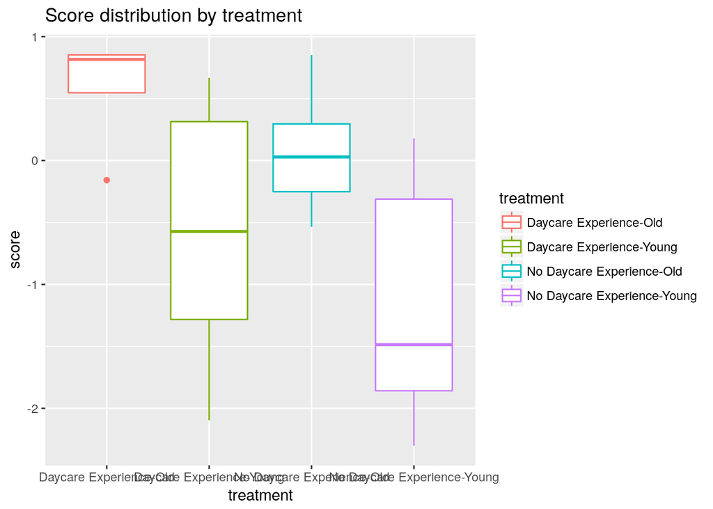

```r
treatments.plot
```

Density:

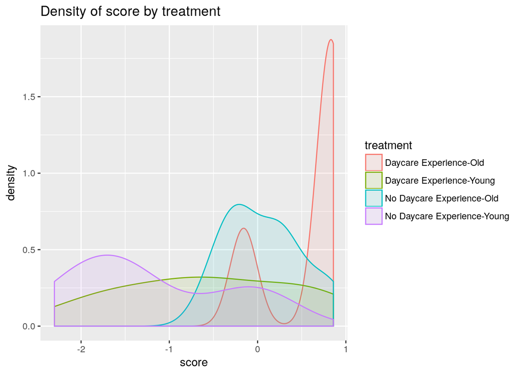

```r
density.plot
```

## ANOVAs

```r
daycare.ezanova
```

```
## $ANOVA
##      Effect DFn DFd        F         p p<.05        ges
## 2 daycare.f   1  38 1.414537 0.2416835       0.03588871
##
## $`Levene's Test for Homogeneity of Variance`
##   DFn DFd        SSn      SSd          F         p p<.05
## 1   1  38 0.02605183 13.67923 0.07237025 0.7893717
```